# Introduction to Data Analysis in R - Machine Learning Workflow

# Machine Learning Example

Machine learning has been a very popular way of building predictive models. It’s popularity is largely due to the simplicity of the modeling process.

## Oral toxicity dataset

We will be using a publicly available data set of oral toxicity of a set of ~10k compounds. Each compound is described by presence or absence of 1024 structural features.

### Data download

```r
temp=tempfile()
download.file("https://archive.ics.uci.edu/ml/machine-learning-databases/00508/qsar_oral_toxicity.zip", temp)
tox = read.csv(unz(temp, "qsar_oral_toxicity.csv"), sep=";")
install.packages(c("caret", "doParallel", "pROC", "randomForest", "kernlab", "glmnet"))
```

[output not shown]

[output not shown]

[output not shown]

[output not shown]

[output cut: 10 more lines]

[output not shown]

[output not shown]

[output not shown]

[output not shown]

[output not shown]

[output cut: 88 more lines]

[output not shown]

[output not shown]

[output not shown]

[output cut: 88 more lines]

[output not shown]

[output not shown]

[output not shown]

[output cut: 88 more lines]

[output not shown]

[output not shown]

[output not shown]

[output not shown]

[output not shown]

```r
unlink(temp)
```

Let’s take a brief look at the data

```r
list(
  dim=dim(tox),
  outcome=table(tox$negative)
)
```

```
$dim
[1] 8991 1025

$outcome

negative positive
    8250      741
```

```r
head(tox, 2)
```

|  | X0 | X0.1 | X0.2 | X0.3 | X0.4 | X0.5 | X0.6 | X0.7 | X0.8 | X0.9 | X1 | X0.10 | X0.11 | X0.12 | X0.13 | X0.14 | X1.1 | X0.15 | X0.16 | X0.17 | X0.18 | X0.19 | X0.20 | X0.21 | X0.22 | X0.23 | X0.24 | X0.25 | X0.26 | … |
| --- | --- | --- | --- | --- | --- | --- | --- | --- | --- | --- | --- | --- | --- | --- | --- | --- | --- | --- | --- | --- | --- | --- | --- | --- | --- | --- | --- | --- | --- | --- |
| 1 | 0 | 0 | 1 | 0 | 0 | 0 | 0 | 0 | 0 | 0 | 1 | 0 | 0 | 0 | 0 | 0 | 1 | 0 | 0 | 0 | 0 | 0 | 0 | 0 | 0 | 0 | 0 | 0 | 0 | … |
| 2 | 0 | 0 | 0 | 0 | 0 | 0 | 0 | 0 | 0 | 0 | 1 | 0 | 0 | 0 | 0 | 0 | 1 | 0 | 0 | 0 | 0 | 0 | 0 | 0 | 0 | 0 | 0 | 0 | 0 | … |

```r
head(tox[, order(ncol(tox):1)], 2)
```

|  | negative | X0.970 | X0.969 | X0.968 | X0.967 | X0.966 | X0.965 | X0.964 | X0.963 | X0.962 | X0.961 | X0.960 | X0.959 | X0.958 | X0.957 | X0.956 | X0.955 | X0.954 | X0.953 | X0.952 | X0.951 | X0.950 | X0.949 | X0.948 | X0.947 | X0.946 | X0.945 | X0.944 | X0.943 | … |
| --- | --- | --- | --- | --- | --- | --- | --- | --- | --- | --- | --- | --- | --- | --- | --- | --- | --- | --- | --- | --- | --- | --- | --- | --- | --- | --- | --- | --- | --- | --- |
| 1 | negative | 0 | 0 | 0 | 0 | 0 | 0 | 0 | 0 | 0 | 0 | 0 | 0 | 0 | 0 | 0 | 0 | 1 | 0 | 0 | 0 | 0 | 0 | 0 | 0 | 0 | 0 | 0 | 0 | … |
| 2 | negative | 0 | 0 | 0 | 0 | 0 | 0 | 1 | 0 | 0 | 0 | 0 | 0 | 0 | 0 | 0 | 0 | 0 | 0 | 0 | 0 | 0 | 0 | 0 | 0 | 0 | 0 | 0 | 0 | … |

We confirm that we have 1024 binary features and one target (positive/negative). The dataset is heavily imbalanced, only 8% of compounds are toxic.

## ML modeling pipeline

There are literally hundrends of libraries that we can use. A good starting set of tools is in `caret` and I recommend using it. The [documentation](https://topepo.github.io/caret/) is excellent, and reading it on its own is like a Machine Learning course.

In fact `caret` is so good, that Python folk are now trying to replicate it with py-caret.

```r
require(caret)
# parallel registration
require(doParallel)
cl = makePSOCKcluster(detectCores() - 1)
registerDoParallel(cl)
```

Let’s check for missing values and deduplicate the data. It’s often the first step of any analysis.

```r
anyNA(tox)
```

```
[1] FALSE
```

```r
dupes = duplicated(tox)
sum(dupes)
```

```
[1] 477
```

```r
tox = tox[!dupes,]
```

### Splitting data

The data is always split into train/validation/test sets. Let’s first split into train/test. We will then split the train when we discuss why we need the validation set.

```r
tIdx = createDataPartition(tox$negative, p=0.75, list=F)
length(tIdx)
```

```
[1] 6387
```

```r
head(tIdx, 10)
```

```
      Resample1
 [1,]         1
 [2,]         2
 [3,]         3
 [4,]         4
 [5,]         8
 [6,]         9
 [7,]        10
 [8,]        13
 [9,]        14
[10,]        16
```

Let’s take a look at the positive/negative rates in our training/testing samples (we’d like them to be the same).

```r
table(tox[tIdx, "negative"])
```

```
negative positive
    5847      540
```

```r
table(tox[-tIdx, "negative"])
```

```
negative positive
    1948      179
```

We now *completely forget* about the testing data. As if it *didn’t exist*. We will get back to it after all models are trained and cross-checked.

```r
train.data = tox[tIdx,]
train.X = train.data[, 1:(ncol(train.data) - 1)]
train.y = train.data["negative"]


test.data = tox[-tIdx,]
test.X = test.data[, 1:(ncol(test.data) - 1)]
test.y = test.data["negative"]
```

### Pre-processing

Pre-processing aims to reduce the complexity of the features so that the ML models train easier. Most often *domain knowledge* allows one to perform at least some pre-processing.

```r
#Let's check if there are any features that occur only 1-time in the dataset. These are obviously not going to be predictive, because one can't generalize from a feature seen only once.
any(colSums(train.X) == 1)
```

```
[1] FALSE
```

```r
# Let's check if there are features that are present for every sample
any(colSums(train.X) == nrow(train.X))
```

```
[1] FALSE
```

```r
# Let's see if some features are duplicates of other features?
any(duplicated(t(train.X)))
```

```
[1] FALSE
```

```r
# Let's see if some of the input sampels (both X and y) are duplicates
any(duplicated(train.data))
```

```
[1] FALSE
```

Question:

Why is pre-processing done after the data was split into train/test?

Answer: If we start selecting features, this can introduce bias into the test set (hence, overfitting or underfitting the model).

### Cross-validation.

Machine learning models require some level of control while training to limit the effect of overfitting. Overfitting arises because in ML one typically uses many many features and a flexible model formulation, so without *control* the models would simply replicate the training data, while not learn anything. The degrees of freedom of the fit are often larger than the data set itself so *control* is a must.

```r
samples = createDataPartition(train.data$negative, p=0.75, times=5, list=TRUE)

ctrl = trainControl(method='LGOCV',
                    p=0.75,
                    number=5,
                    index=samples,
                    sampling='down', # this is critical when handling class imbalance problems
                    classProbs=TRUE,
                    summaryFunction=twoClassSummary,
                    savePredictions=TRUE
                    )
```

There is a lot happening in this *control*. So let’s talk over it.

A brief note on the evaluation metrics
$$Specificity = 1 - \frac{False Positives}{Positives}
\\
Sensitivity = 1 - \frac{False Negatives}{Negatives}$$

It’s always possible to make Specificity or Sensitivity 1, but not both. ROC curve (and it’s area under curve [AUC]) determines how well we can balance good sensitivity with good specificity.

### Model training with overfitting control

We will train a handful of models. The control is used to choose an appropriate set of hyper-parameters. For each modeling method the list of hyper-parameters can be checked with `caret::modelLookup(model_name)`.

First `random forest`.

```r
require('randomForest')
modelLookup('rf')
```

|  | model | parameter | label | forReg | forClass | probModel |
| --- | --- | --- | --- | --- | --- | --- |
| 1 | rf | mtry | #Randomly Selected Predictors | TRUE | TRUE | TRUE |

```r
rf.model = train(negative ~ ., data=train.data, method='rf', trControl=ctrl,
                 metric='ROC', ntree=10, tuneGrid=expand.grid(mtry=c(2,5,10,15,20)))
rf.model
```

```
Random Forest

6387 samples
1024 predictors
   2 classes: 'negative', 'positive'

No pre-processing
Resampling: Repeated Train/Test Splits Estimated (5 reps, 75%)
Summary of sample sizes: 4791, 4791, 4791, 4791, 4791
Addtional sampling using down-sampling

Resampling results across tuning parameters:

  mtry  ROC        Sens       Spec
   2    0.7743261  0.7457906  0.6785185
   5    0.8092610  0.7733060  0.7007407
  10    0.8256577  0.7941136  0.7185185
  15    0.8243461  0.8091718  0.6948148
  20    0.8323487  0.7911020  0.7303704

ROC was used to select the optimal model using the largest value.
The final value used for the model was mtry = 20.
```

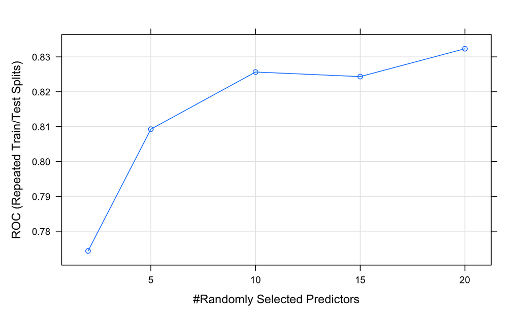

```r
plot(rf.model)
```

Then `support vector machines`. All it takes in `caret` is to change the `method` and adapt the hyperparameters.

```r
require('kernlab')
modelLookup('svmRadialCost')
```

|  | model | parameter | label | forReg | forClass | probModel |
| --- | --- | --- | --- | --- | --- | --- |
| 1 | svmRadialCost | C | Cost | TRUE | TRUE | TRUE |

```r
svm.model = train(negative ~ ., data=train.data, method='svmRadialCost', trControl=ctrl,
                 metric='ROC', tuneGrid=expand.grid(C=c(0.5, 1, 1.5, 2)))
svm.model
```

```
Support Vector Machines with Radial Basis Function Kernel

6387 samples
1024 predictors
   2 classes: 'negative', 'positive'

No pre-processing
Resampling: Repeated Train/Test Splits Estimated (5 reps, 75%)
Summary of sample sizes: 4791, 4791, 4791, 4791, 4791
Addtional sampling using down-sampling

Resampling results across tuning parameters:

  C    ROC        Sens       Spec
  0.5  0.8414749  0.8537988  0.7037037
  1.0  0.8431724  0.8450376  0.6992593
  1.5  0.8460643  0.8224504  0.7244444
  2.0  0.8472021  0.8212183  0.7362963

ROC was used to select the optimal model using the largest value.
The final value used for the model was C = 2.
```

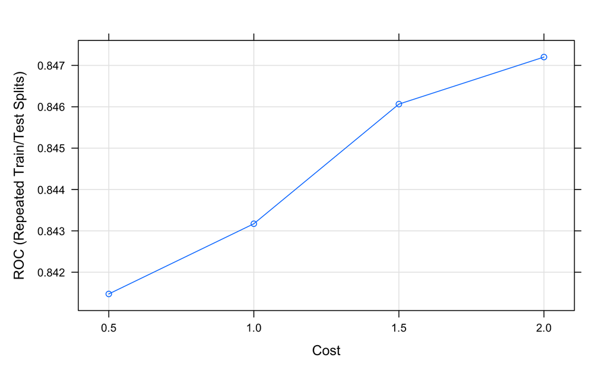

```r
plot(svm.model)
```

Now the simplest linear model `glmnet` which stands for Elastic-Net Regression.

```r
require('glmnet')
modelLookup('glmnet')
```

|  | model | parameter | label | forReg | forClass | probModel |
| --- | --- | --- | --- | --- | --- | --- |
| 1 | glmnet | alpha | Mixing Percentage | TRUE | TRUE | TRUE |
| 2 | glmnet | lambda | Regularization Parameter | TRUE | TRUE | TRUE |

```r
glmnet.model = train(negative ~ ., data=train.data, method='glmnet', trControl=ctrl,
                 metric='ROC', tuneGrid=expand.grid(alpha=1,
                                                    lambda=c(0.00001, 0.0001, 0.001,
                                                             0.005, 0.01, 0.03, 0.05)))
glmnet.model
```

```
glmnet

6387 samples
1024 predictors
   2 classes: 'negative', 'positive'

No pre-processing
Resampling: Repeated Train/Test Splits Estimated (5 reps, 75%)
Summary of sample sizes: 4791, 4791, 4791, 4791, 4791
Addtional sampling using down-sampling

Resampling results across tuning parameters:

  lambda  ROC        Sens       Spec
  1e-05   0.7971613  0.7227926  0.7407407
  1e-04   0.7971613  0.7227926  0.7407407
  1e-03   0.7971613  0.7227926  0.7407407
  5e-03   0.8117428  0.7462012  0.7437037
  1e-02   0.8194413  0.7641342  0.7392593
  3e-02   0.8169742  0.8078029  0.6829630
  5e-02   0.7947961  0.8212183  0.6162963

Tuning parameter 'alpha' was held constant at a value of 1
ROC was used to select the optimal model using the largest value.
The final values used for the model were alpha = 1 and lambda = 0.01.
```

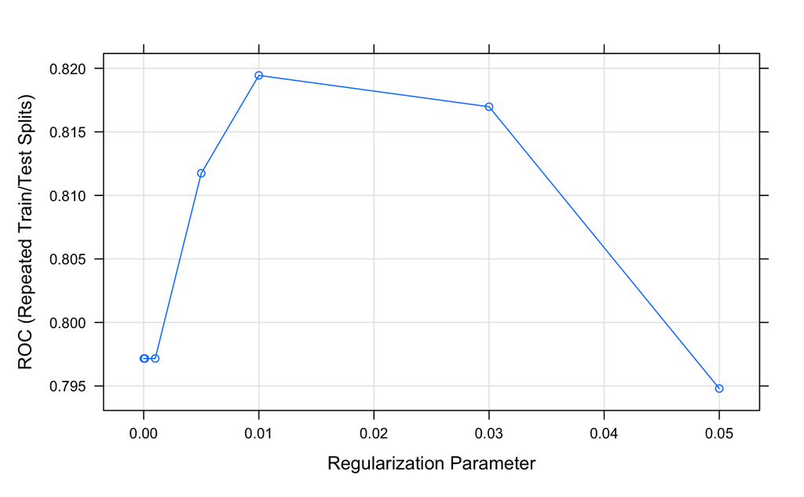

```r
plot(glmnet.model)
```

`Caret` provides plenty of libraries to compare models based on their performance in cross-validation.

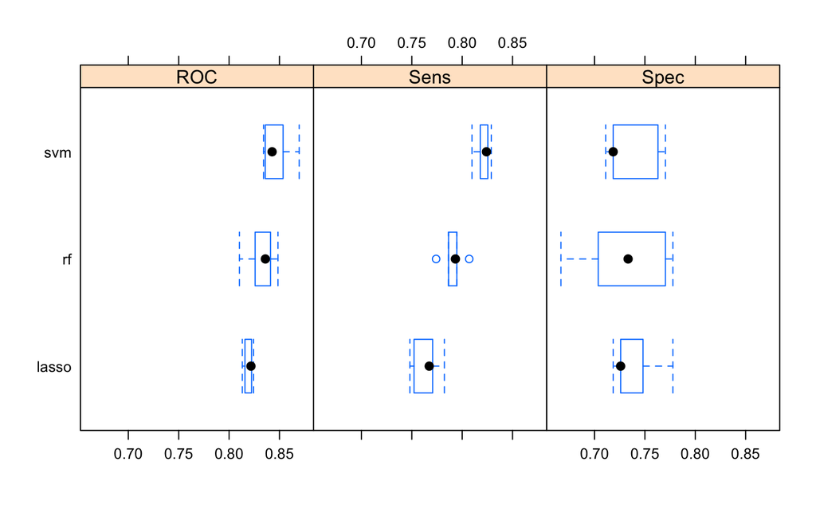

```r
# first we combine the models into a list
models=list(rf=rf.model, svm=svm.model, lasso=glmnet.model)
# extract the prediction information from the cross-validation resampling
resamps = resamples(models)
# plot
bwplot(resamps)
```

Overall SVM tends to narrowly win.

**This is very typical to machine learning problems: many algorithms will perform similarly. What limits the performance is the relevant information stored in the features, and not the algorithm that’s used to build the model.**

Question: how do we choose the final model (let’s say for publication?)

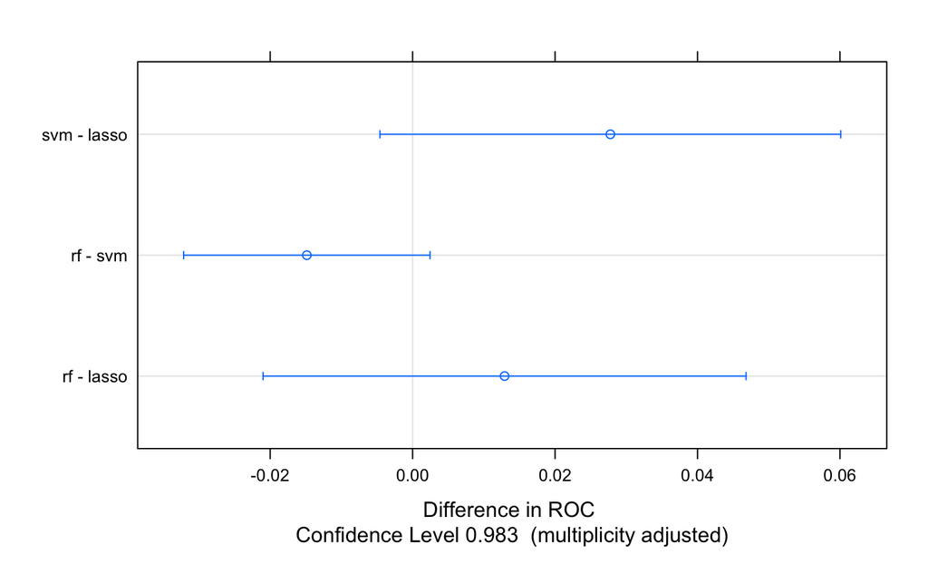

```r
# Caret offers a way to take a look at differences between models. This is nuanced from a statistics point of view that we will not get into here.
resamps.diff = diff(resamps)
dotplot(resamps.diff, metric='ROC')
```

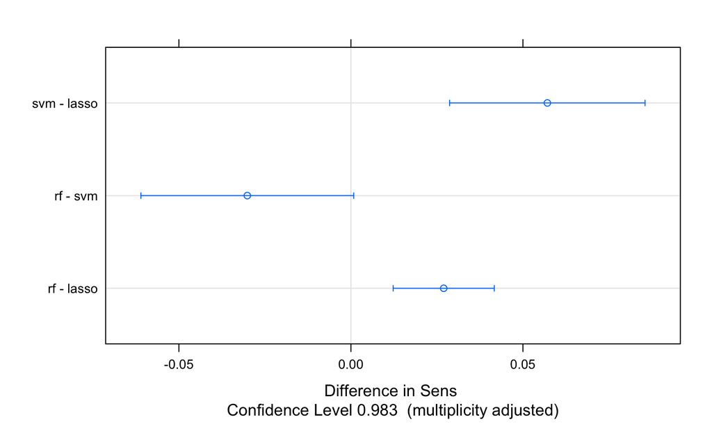

```r
dotplot(resamps.diff, metric='Sens')
```

### Final evaluation of the model

This is always done on a test set that hasn’t been used in any modeling decision, to remain unbiased.

```r
probs = extractProb(models, testX = test.X, testY = test.y$negative)
head(probs,6)
```

|  | negative | positive | obs | pred | model | dataType | object |
| --- | --- | --- | --- | --- | --- | --- | --- |
| 1 | 0.2 | 0.8 | negative | positive | rf | Training | rf |
| 2 | 0.1 | 0.9 | negative | positive | rf | Training | rf |
| 3 | 0.4 | 0.6 | negative | positive | rf | Training | rf |
| 4 | 1.0 | 0.0 | negative | negative | rf | Training | rf |
| 8 | 0.6 | 0.4 | negative | negative | rf | Training | rf |
| 9 | 0.7 | 0.3 | negative | negative | rf | Training | rf |

```r
head(probs,50)
```

|  | negative | positive | obs | pred | model | dataType | object |
| --- | --- | --- | --- | --- | --- | --- | --- |
| 1 | 0.2 | 0.8 | negative | positive | rf | Training | rf |
| 2 | 0.1 | 0.9 | negative | positive | rf | Training | rf |
| 3 | 0.4 | 0.6 | negative | positive | rf | Training | rf |
| 4 | 1.0 | 0.0 | negative | negative | rf | Training | rf |
| 8 | 0.6 | 0.4 | negative | negative | rf | Training | rf |
| 9 | 0.7 | 0.3 | negative | negative | rf | Training | rf |
| 10 | 0.5 | 0.5 | negative | negative | rf | Training | rf |
| 13 | 0.4 | 0.6 | negative | positive | rf | Training | rf |
| 14 | 0.3 | 0.7 | negative | positive | rf | Training | rf |
| 16 | 0.8 | 0.2 | negative | negative | rf | Training | rf |

[output cut: 40 more lines]

Let’s plot some ROC curves for our models.

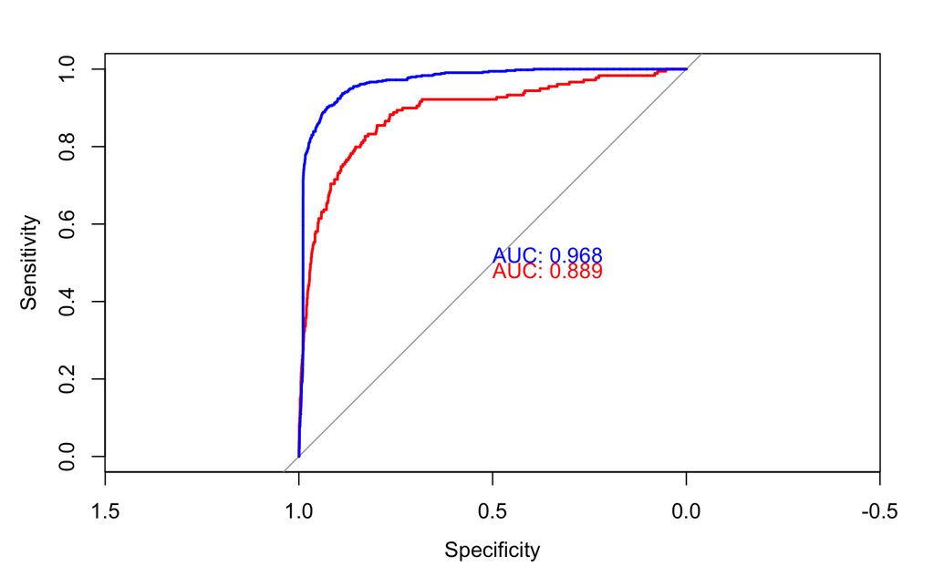

```r
require(pROC)
probs.test.svm = probs[probs$dataType=='Test' & probs$model=='svmRadialCost', ]
probs.train.svm = probs[probs$dataType=='Training' & probs$model=='svmRadialCost', ]

roc.svm.test = pROC::roc(probs.test.svm$obs, probs.test.svm$negative)
roc.svm.train = pROC::roc(probs.train.svm$obs, probs.train.svm$negative)
plot.roc(roc.svm.test, print.auc=TRUE, col='red')
plot.roc(roc.svm.train, print.auc=TRUE, add=TRUE, col='blue', print.auc.adj=c(0,0))
```

```r
probs.test.svm = probs[probs$dataType=='Test' & probs$model=='svmRadialCost', ]
probs.test.rf = probs[probs$dataType=='Test' & probs$model=='rf', ]
probs.test.lasso = probs[probs$dataType=='Test' & probs$model=='glmnet', ]

roc.svm.test = pROC::roc(probs.test.svm$obs, probs.test.svm$negative)
roc.rf.test = pROC::roc(probs.test.rf$obs, probs.test.rf$negative)
roc.lasso.test = pROC::roc(probs.test.lasso$obs, probs.test.lasso$negative)
plot.roc(roc.svm.test, print.auc=TRUE, col='red')
plot.roc(roc.rf.test, print.auc=TRUE, add=TRUE, col='blue', print.auc.adj=c(-1,2))
```

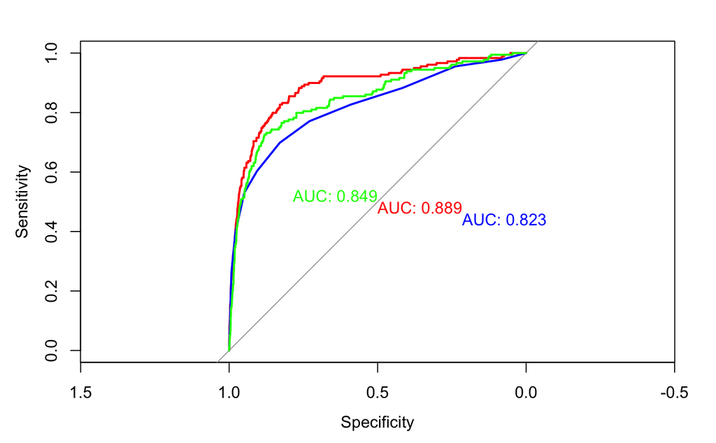

```r
plot.roc(roc.lasso.test, print.auc=TRUE, add=TRUE, col='green', print.auc.adj=c(1,0))
```

Finally, let’s print the confusion matrix and other metric of our top models on the test set.

```r
confusionMatrix(probs.test.svm$pred, probs.test.svm$obs)
```

```
Confusion Matrix and Statistics

          Reference
Prediction negative positive
  negative     1622       33
  positive      326      146

               Accuracy : 0.8312
                 95% CI : (0.8146, 0.8469)
    No Information Rate : 0.9158
    P-Value [Acc > NIR] : 1

                  Kappa : 0.3719

 Mcnemar's Test P-Value : <2e-16

            Sensitivity : 0.8326
            Specificity : 0.8156
         Pos Pred Value : 0.9801
         Neg Pred Value : 0.3093
             Prevalence : 0.9158
         Detection Rate : 0.7626
   Detection Prevalence : 0.7781
      Balanced Accuracy : 0.8241

       'Positive' Class : negative
```

```r
confusionMatrix(probs.test.rf$pred, probs.test.rf$obs)
```

```
Confusion Matrix and Statistics

          Reference
Prediction negative positive
  negative     1616       54
  positive      332      125

               Accuracy : 0.8185
                 95% CI : (0.8015, 0.8347)
    No Information Rate : 0.9158
    P-Value [Acc > NIR] : 1

                  Kappa : 0.3096

 Mcnemar's Test P-Value : <2e-16

            Sensitivity : 0.8296
            Specificity : 0.6983
         Pos Pred Value : 0.9677
         Neg Pred Value : 0.2735
             Prevalence : 0.9158
         Detection Rate : 0.7598
   Detection Prevalence : 0.7851
      Balanced Accuracy : 0.7639

       'Positive' Class : negative
```